# Singapore’s Demographic Composition Across Time Dataviz Makeover Exercise #8

## 3.4 Creating a Static Ternary Plot

Ternary plots are useful to simultaneously visualise three measures, specifically the ternary composition of the three broad age groups, the young, working age and aged. To build static ternary plots, the **ggtern** package can be used. For a start, the age composition of planning areas across Singapore in the year 2019 is visualised. Additional aesthetics are mapped to encode several dimensions onto the same graph: - `fill = Region` - to color code the data points by Region - `size = Population` - to vary the size of the data points by population size

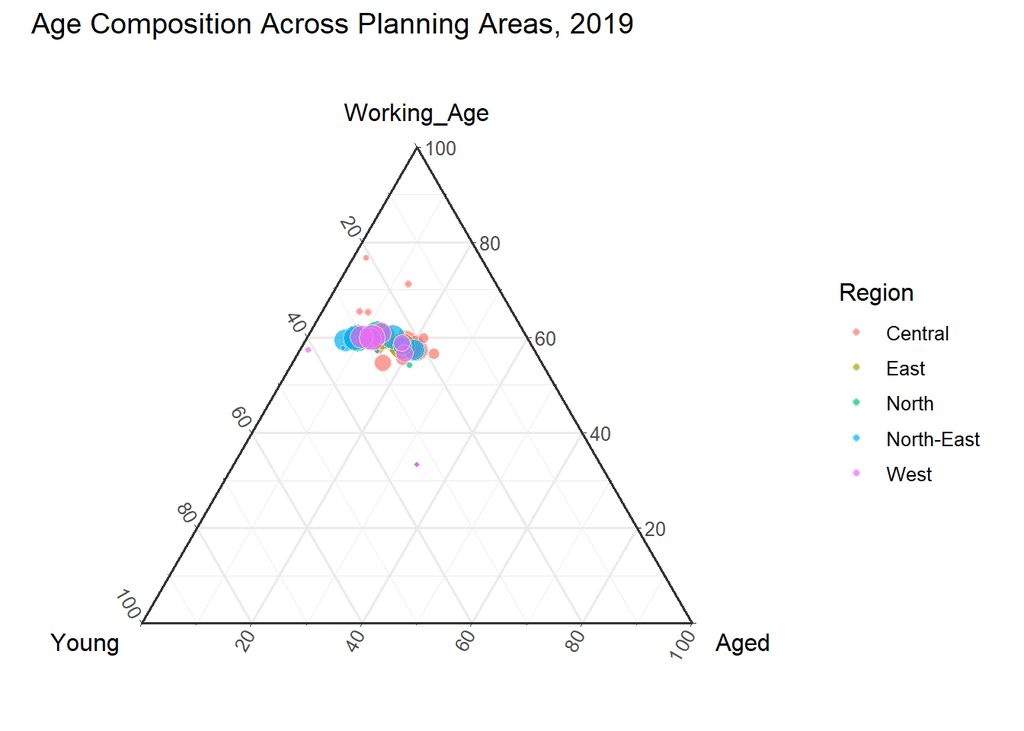

```r
tern_2019 <- spread_pop_ag %>%
  filter(Year=='2019') %>%
  ggtern(aes(x=Young,y=Working_Age, z=Aged, fill= Region, size=Population)) +
  geom_point(alpha=0.7,shape=21, color="white") +
  guides(size = FALSE) +
  theme_bw() +
  ggtitle("Age Composition Across Planning Areas, 2019")

tern_2019
```

The datapoints representing the age composition of different planning areas are mostly clustered together around the same region on the ternary graph, therefore difficult to interpret. The graph can be improved by adjusting the ternary scales. This is achieved by passing a vector specifying the limits into the functions `scale_T_continuous`, `scale_L_continuous` and `scale_R_continuous`.

Additional touch-up has been made by adding arrows, arrow labels and vertex labels.

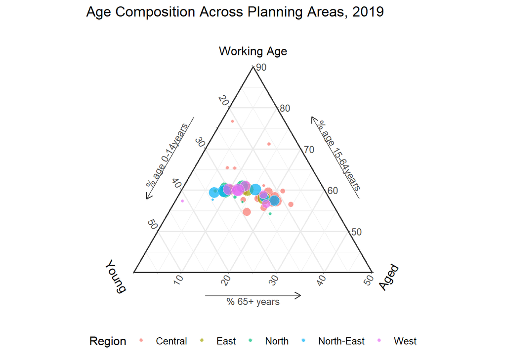

```r
tern_2019 +
  scale_T_continuous(limits=c(0.4,0.9)) +
  scale_L_continuous(limits=c(0.1,0.6)) +
  scale_R_continuous(limits=c(0,0.5))+
  theme_showarrows() +
  labs( x       = "Young",
      xarrow  = "% age 0-14years",
      y       = "Working Age",
      yarrow  = "% age 15-64years",
      z       = "Aged",
      zarrow  = "% 65+ years") +
  theme(legend.position = "bottom",
          legend.box = "horizontal",
        tern.axis.title.T = element_text(),
          tern.axis.title.L = element_text(hjust = 0.2, vjust = 0.7, angle = -60),
          tern.axis.title.R = element_text(hjust = 0.8, vjust = 0.6, angle = 60))
```

To visualise the age compositions across time, trellis of ternary graphs (aka faceting) can be created. This is simply done by adding `facet_wrap(. ~ Year)`.

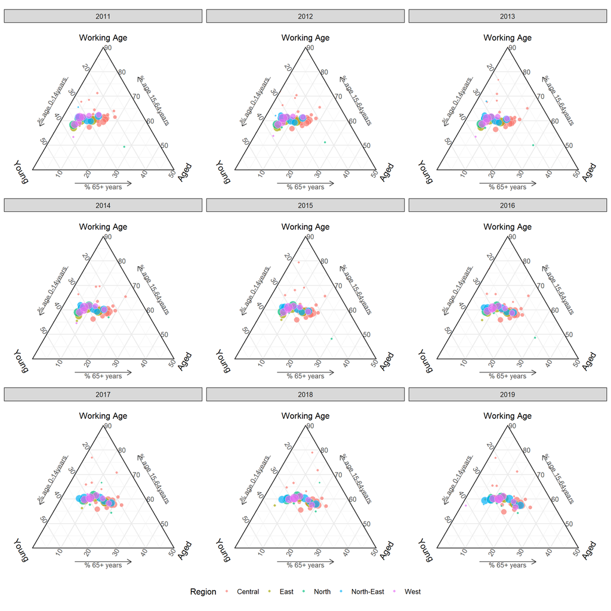

```r
tern_all <- ggtern(data=spread_pop_ag, aes(x=Young,y=Working_Age, z=Aged, fill= Region, size=Population)) +
  geom_point(alpha=0.7, shape=21, color="white") +
  guides(size = FALSE) +
  facet_wrap(. ~ Year)

tern_all +
  theme_bw() +
  scale_T_continuous(limits=c(0.4,0.9)) +
  scale_L_continuous(limits=c(0.1,0.6)) +
  scale_R_continuous(limits=c(0,0.5))+
  theme_showarrows() +
  labs( x       = "Young",
      xarrow  = "% age 0-14years",
      y       = "Working Age",
      yarrow  = "% age 15-64years",
      z       = "Aged",
      zarrow  = "% 65+ years") +
  theme(legend.position = "bottom",
          legend.box = "horizontal",
        tern.axis.title.T = element_text(),
          tern.axis.title.L = element_text(hjust = 0.2, vjust = 0.7, angle = -60),
          tern.axis.title.R = element_text(hjust = 0.8, vjust = 0.6, angle = 60))
```